# What Wins NBA Games?

3/24/2022

### **Objective**

The main purpose of this study will be to use multiple linear regression to determine which stats win ball games. Once determined, we will be able to prove or disprove any of the many historical hypotheses or claims. For example, many claim that defensive stats win games, this is an older theory. Counter to that, in the modern basketball era, many believe that 3-point shooting is most important in winning games. This study will test both of these as well as any other possible stat that may have an influence on wins. Further, this study will determine what franchise owners should look for when building a team.

### Data Set

This data set includes 448 observations, translating to 15 seasons (two 29 team seasons and 13 30 team seasons). These seasons are consecutive starting with the 2002-2003 season up to the 2016-2017 season. This data set includes 13 variables. 12 of which are numerical and one is categorical which is season.

### **Exploratory Data Analysis (EDA)**

| Summary Statistic | Wins | FG % | 3-pt % | 2-pt % | Free Throw % | Offensive Rebounds | Deffensive Rebounds | Assists | Steals | Blocks | Turnovers | Personal Fouls |
| --- | --- | --- | --- | --- | --- | --- | --- | --- | --- | --- | --- | --- |
| Min | 7 | 0.408 | 0.278 | 0.43 | 0.66 | 7.6 | 26.9 | 17.4 | 5.5 | 2.5 | 11.2 | 16.6 |
| Mean | 40.451 | 0.453 | 0.354 | 0.483 | 0.757 | 11.16 | 31.002 | 21.569 | 7.554 | 4.863 | 14.468 | 20.993 |
| Median | 41 | 0.452 | 0.353 | 0.481 | 0.758 | 11.1 | 30.8 | 21.35 | 7.5 | 4.8 | 14.5 | 20.9 |
| Max | 73 | 0.504 | 0.416 | 0.558 | 0.829 | 15.7 | 36.2 | 30.4 | 10.3 | 8.2 | 18.5 | 26.7 |
| STDEV | 12.453 | 0.016 | 0.02 | 0.021 | 0.029 | 1.255 | 1.781 | 1.845 | 0.866 | 0.809 | 1.168 | 1.691 |

##### Wins

The variable wins is a quantitative variable of integer type. This is the number of wins by a team in a season. We can see from the histogram below that its distribution is relatively normal and the highest frequency is centered around its corresponding mean of 40.451. The maximum amount of wins a team can have is 82 as that is how many games there are in a season. However, we can see that the max in this data set is 73. We can see from the histogram that very few teams win more than 60 games in a season let alone more than 70.

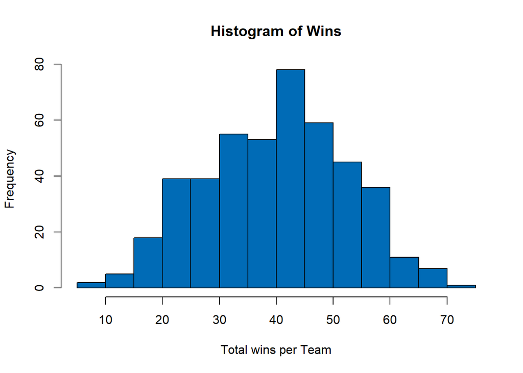

##### Field Goal Percentage

The variable field goal % is a quantitative variable. This is the percentage of all shots from the field made by a team. Each observation is a per game average for a particular team over a season. We can see from the histogram below that the distribution is relatively normal and centered around its mean of 45.3%. With a relatively small standard deviation of 1.6%. We can see that no team shoots below 40% from the field and very few teams shoot above 50%.

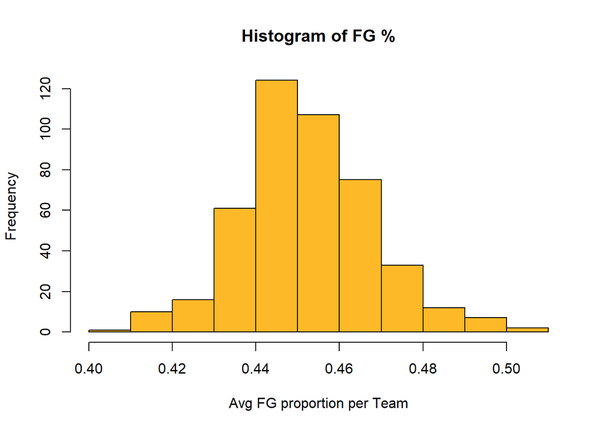

##### 3 Point Percentage

The variable 3-pt % is a quantitative variable. This is the percentage of all shots from the 3 point range made by a team. Each observation is a per game average for a particular team over a season. We can see from the histogram below that the distribution is relatively normal with a few outliers. Most of the distribution is centered around its mean of 35.4%. We can see that there are very few outliers shooting below 30% from 3 point range. It will be interesting to see if this variable is proven to be a significant predictor of wins and therefore if these outliers with low 3-pt shooting % correspondingly have fewer wins. Conversely we will also see if the few outliers with 3-pt shooting % above 40% have correspondingly more wins.

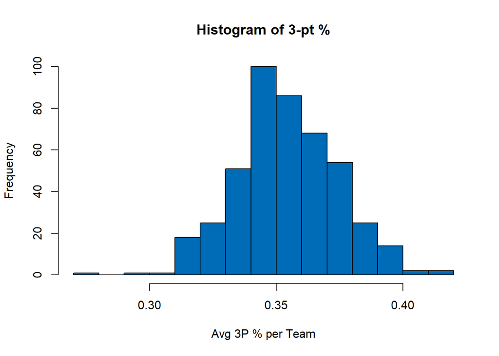

##### 2 Point Percentage

The variable 2-pt % is a quantitative variable. This is the percentage of all shots within 2 point range made by a team. Each observation is a per game average for a particular team over a season. We can see from the histogram below that the distribution is relatively normal with a few outliers and slightly right-skewed. Most of the observations are centered around its mean of 48.3%. We can see that no teams have 2 point shooting percentages less than 43% or greater than 56%.

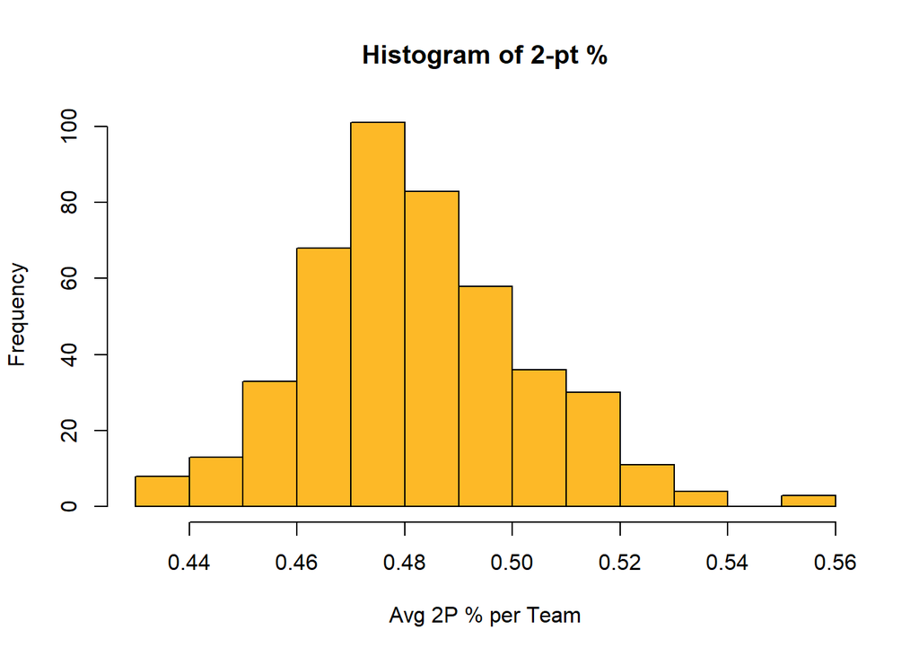

##### Free Throw Percentage

The variable free throw % is a quantitative variable. This is the percentage of all foul shots made by a team. Each observation is a per game average for a particular team over a season. We can see from the histogram below that the distribution is relatively normal and centered around its mean of 75.7%. We can see that no team shoots above 86% or below 66% from the foul line.

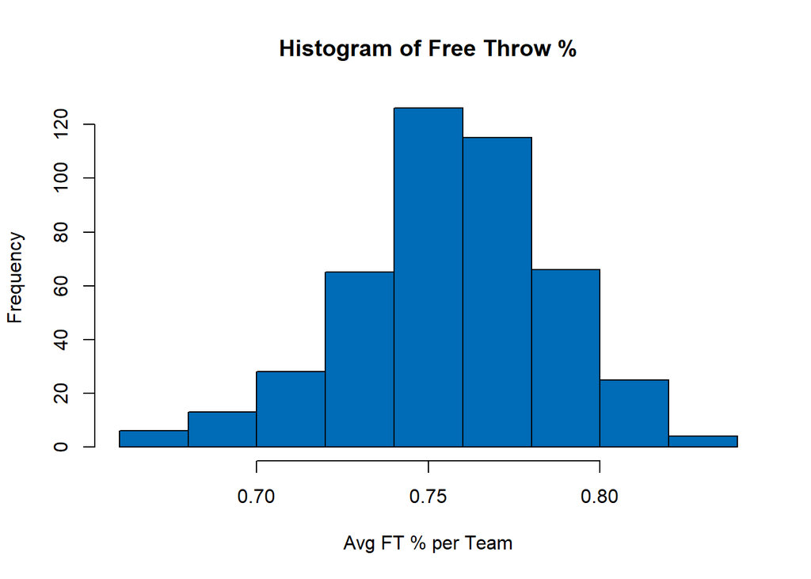

##### Offensive Rebounds

The variable offensive rebounds is a quantitative variable. This is total amount of offensive rebounds by a team per game averaged over a season. We can see from the histogram below that the distribution is relatively normal and centered around its mean of 11.16.

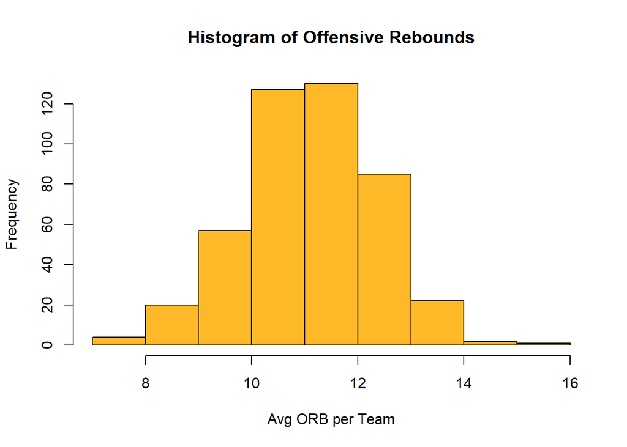

##### Defensive Rebounds

The variable defensive rebounds is a quantitative variable. This is total amount of defensive rebounds by a team per game averaged over a season. We can see from the histogram below that the distribution is slightly right skewed. We can also see that the histogram has more bars compared to offensive rebounds. This is likely because teams average more defensive rebounds than offensive providing a larger range. This makes sense as when a team is defending they have more players crowded under the net waiting for a rebound compared to when they are on offense, players are more spread out to create shooting space.

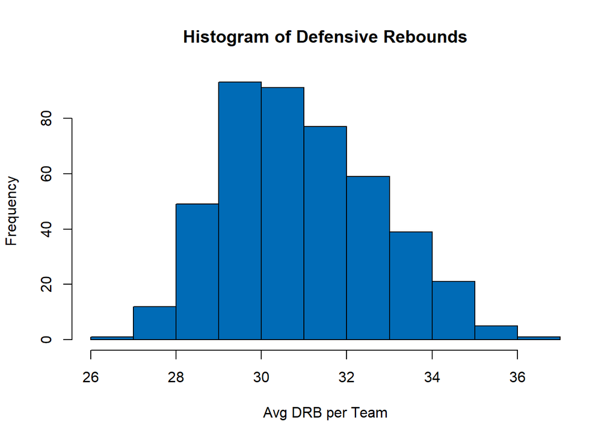

##### Assists

The variable assists is a quantitative variable. This is total amount of assists by a team per game averaged over a season. We can see from the histogram below that the distribution is right skewed, even more so than defensive rebounds. This is also confirmed from its mean of 21.569 which is slightly greater than its median of 21.35. From a qualitative view this can possibly be owed to the few amount of teams that run a “pass first” high ball movement offense.

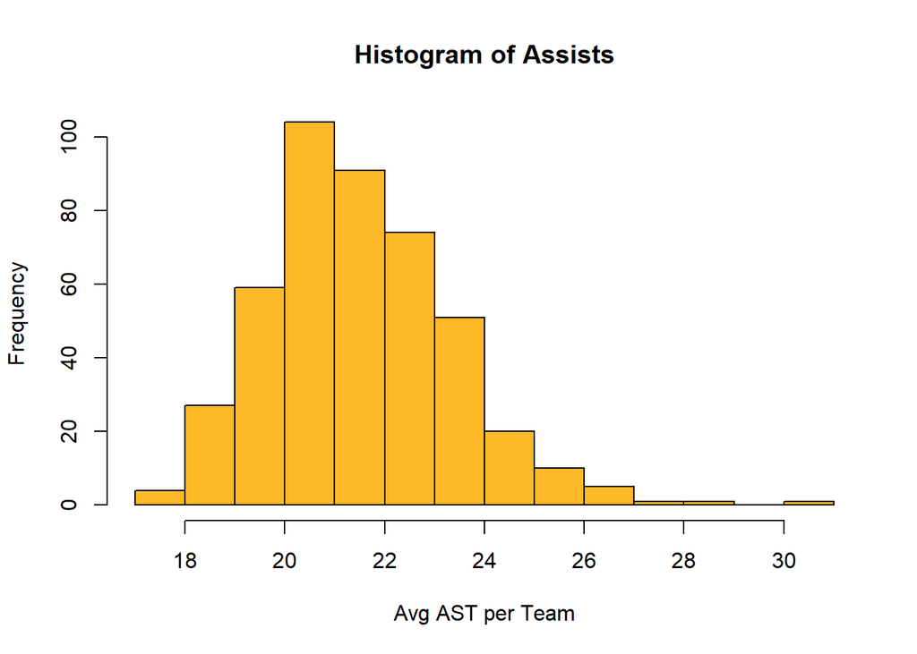

##### Steals

The variable steals is a quantitative variable. This is total amount of steals by a team per game averaged over a season. We can see from the histogram below that the distribution is slightly right skewed with some outliers in the right tails. We can see that very few teams average more than 10 steals.

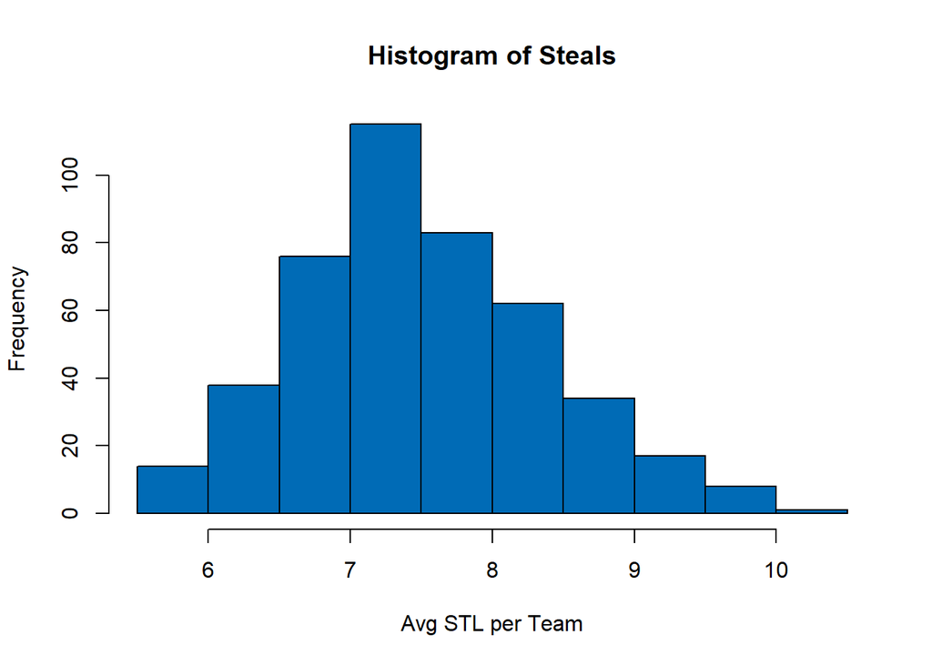

##### Blocks

The variable blocks is a quantitative variable. This is total amount of blocks by a team per game averaged over a season. We can see from the histogram below that the distribution is relatively normal and centered around its mean of 4.863. We can see that there are a few outliers averaging more than 7 blocks. From a qualitative view, this can be accredited to a single player who is known for frequently blocking opponents shots. Such as a player like Theo Ratliff who in the 2003-2004 season averaged 3.61 blocks. We can see in this distribution that is more than some teams.

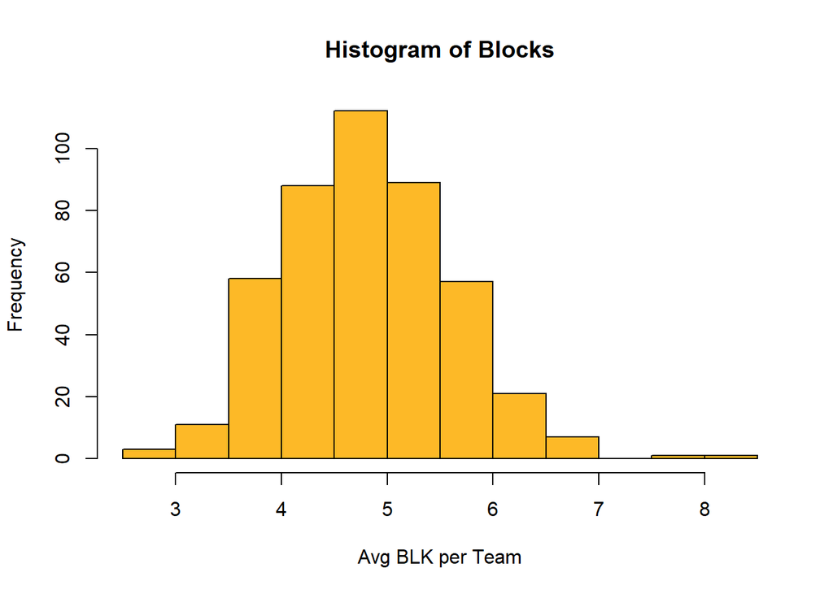

##### Turnovers

The variable turnovers is a quantitative variable. This is total amount of turnovers by a team, per game, averaged over a season. We can see from the histogram below that the distribution is relatively normal and centered around its mean of 14.468. Its median of 14.5 is very close to the mean. We can see that there are very few teams that average more than 17 turnovers. One would assume that having more turnovers would lead to less of a chance of winning. I am curious to see if this variable has a negative coefficient in the regression and if it is significant.

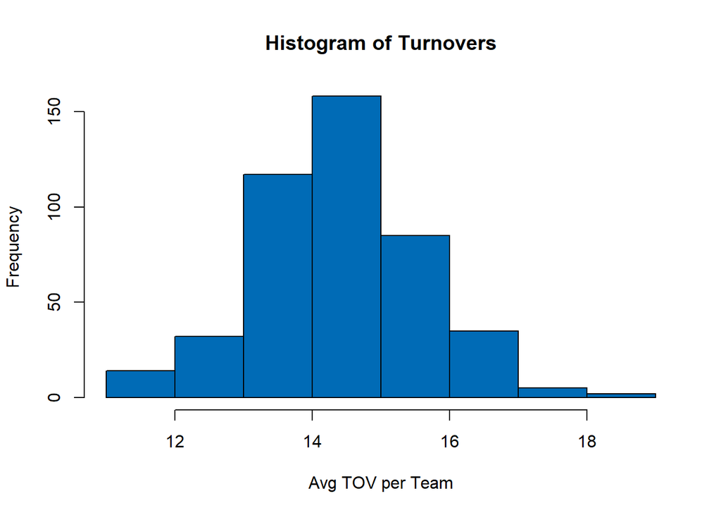

##### Personal Fouls

The variable personal fouls is a quantitative variable. This is total amount of personal fouls by a team per game averaged over a season. We can see from the histogram below that the distribution is relatively normal with only a few observations in the tails. This distribution appears to be centered around its mean of 20.993. Again, like turnovers, a high average of per game personal fouls is likely to have a negative effect on wins.

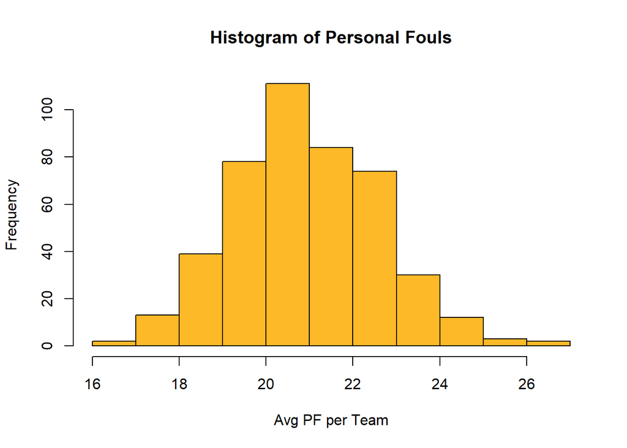

### Relationships

##### Wins, FG %, 2-pt %, 3-pt % and FT %

We can see in the below four scatter plots that field goal %, 3 point % and 2 point % all show a clear positive relationship with wins. Free throw % however, doesn’t show a relationship or pattern with wins.

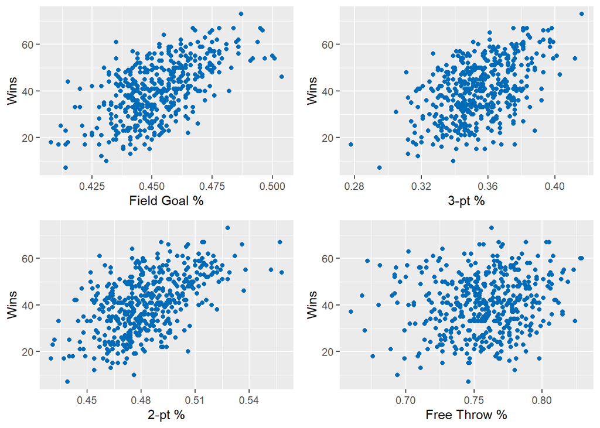

##### Wins, ORB, DRB, AST and STL

We can see in the below four scatter plots that none of these variables show an obvious relationship with wins. There might be a small positive relationship between defensive rebounds and wins. The scatter plot for steals looks as if it was randomly generated. Assists shows a cluster close to the y-intercept. This corresponds to what we saw in its histogram, that it was right skewed.

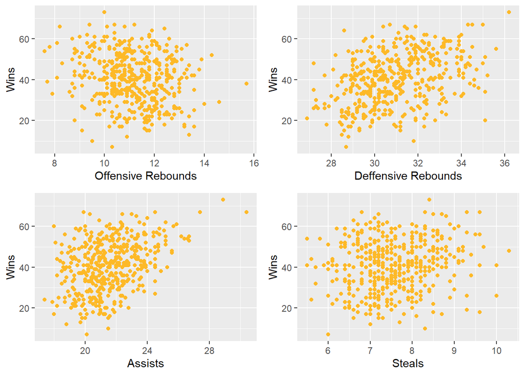

##### W, BLK, TOV, PF, 3-pt % and FG %

We can see in the below four scatter plots a possible negative relationship between wins and turnovers. This would make sense as when a team turns over the ball they lose the opportunity to score and instead give the other team an opportunity to score. It appears that personal blocks and wins don’t have much of a relationship nor do personal fouls and blocks. Last, we can see a clear positive relationship with field goal % and 3-pt %. This makes sense as a 3-pt shot is a shot from the field. The more 3 pointers you make, the more field goals you make.

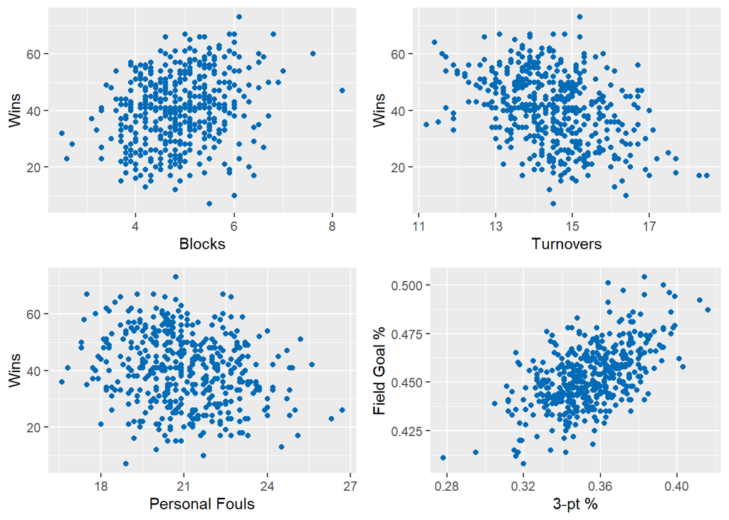

##### FG %, 2-pt %, FT %, ORB and DRB

We can see in the below four scatter plots an obvious positive linear relationship between field goal % and 2-pt %. This is similar to the previously discussed relationship between FG % and 3-pt %. Since a 2 point shot is also from the field and is essentially a function of field goal %. However, this relationship appears to be stronger as teams make more shots from 2 than they do from 3. Overall 2 pointers make up a larger proportion of shots than threes. Following, the other scatter plots show no clear relationships. Other than a small negative relationship between offensive rebounds and FG %. This bares some logic. If a team misses a lot of shots they will have to recover more offensive rebounds.

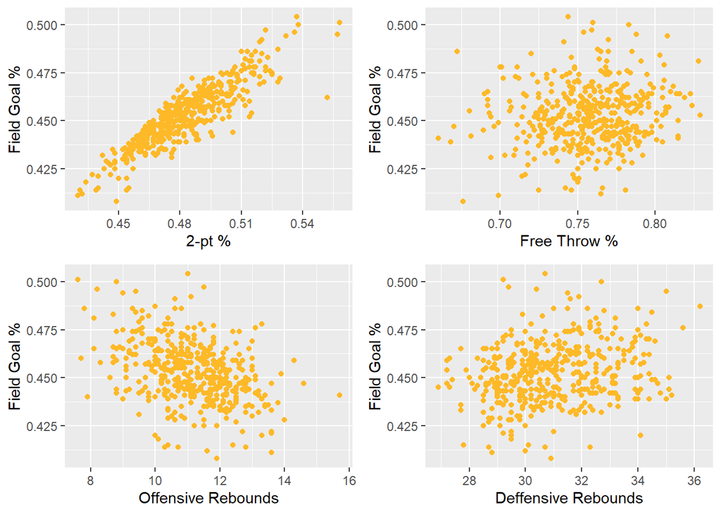

##### FG %, AST, STL, BLK and TOV

We can see in the below four scatter plots a possible small positive relationship between FG% and AST. This makes sense as for an assist to be recorded a shot has to be made. Following that, there doesn’t appear to be any possible relationship in the other 3 plots.

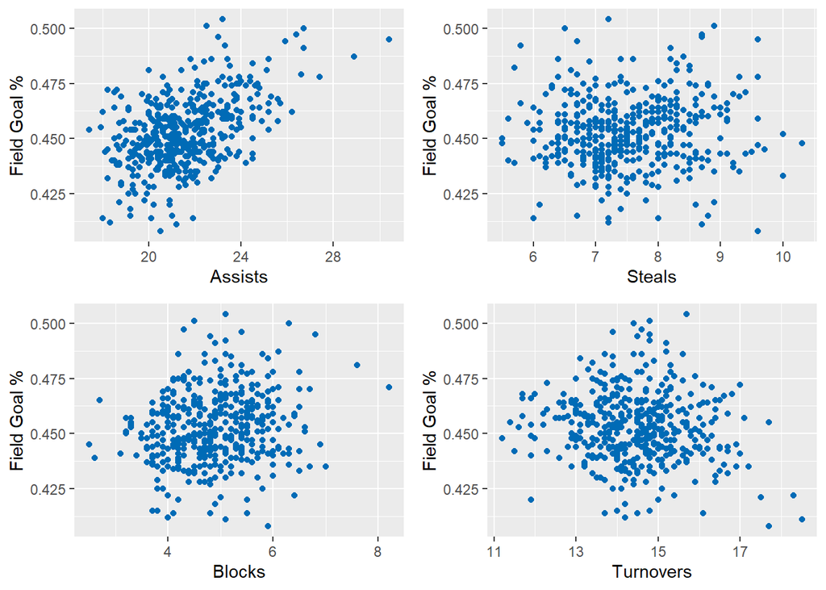

##### FG %, PF, 3-pt %, 2-pt %, FT % and ORB

We can see in the below four scatter plots a positive relationship between 3-pt % and 2-pt %. This makes sense as if a team has good shooters especially from 3 they will likely be good shooters from 2 as well. We see a negative relationship between offensive rebounds and 3-pt %. The logic here is the same as for 2-pt% and offensive rebounds. If a team misses from 3 point range this gives them an opportunity for an offensive rebound.

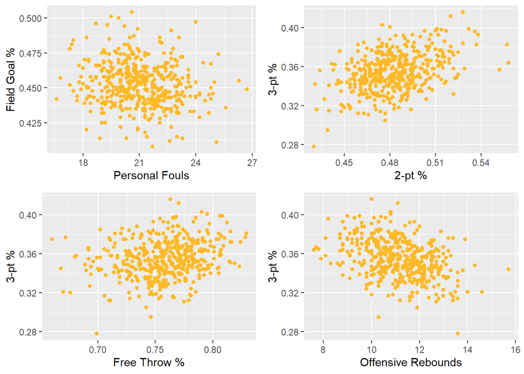

##### 3-pt %, DRB, AST, STL and BLK

In the below four scatter plots, there isn’t much of a visible relationship between any of these variables shown. The points look random.

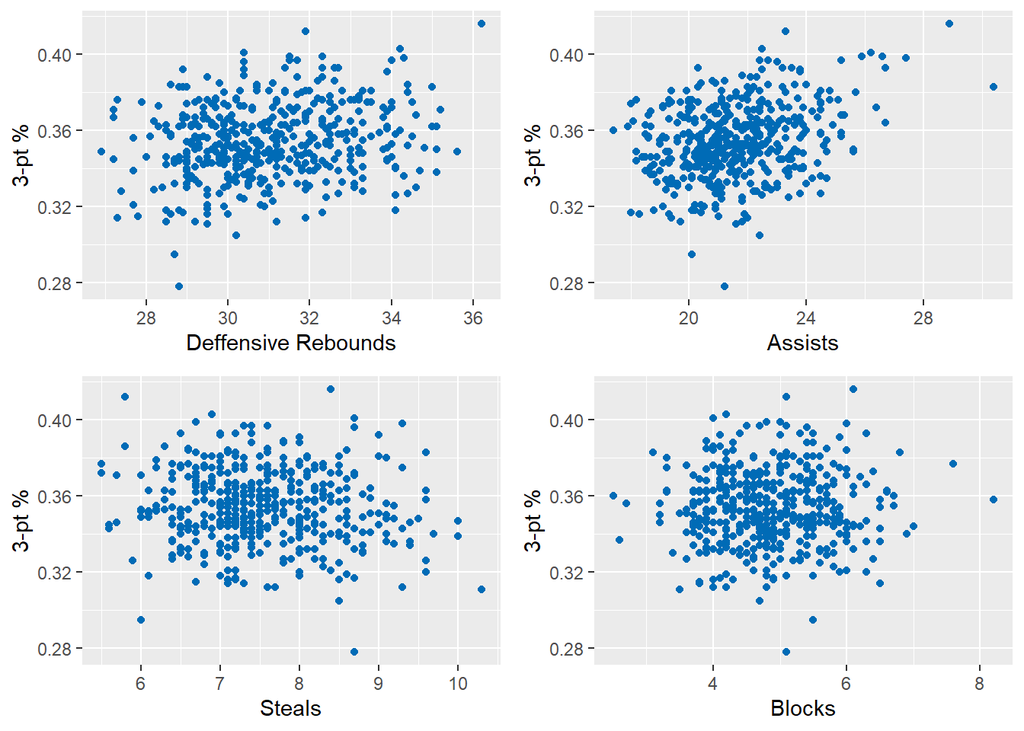

##### 3-pt %, TOV, PF, 2-pt %, FT % and ORB

We can see in the below four scatter plots a negative relationship between 2-pt % and offensive rebounds. The logic here is the same as with 3-pt % and ORB. The more shots that are missed leads to more chances of offensive rebounds. The other three plots show no apparent relationship.

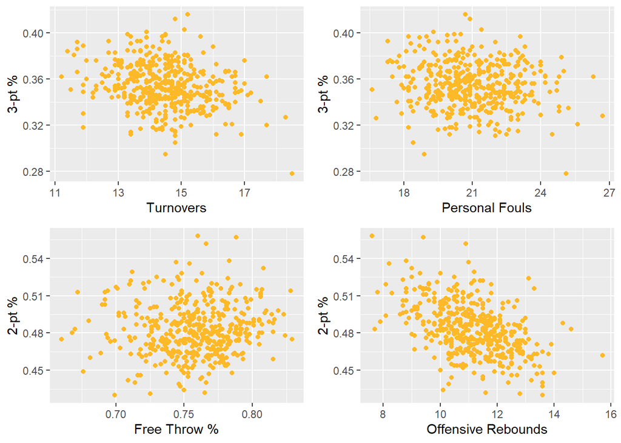

We can see in the below four scatter plots a positive relationship between 2-pt % and assists.The logic here is similar to the relationship between FG % and assists. An assist can only be recorded if a shot is made.

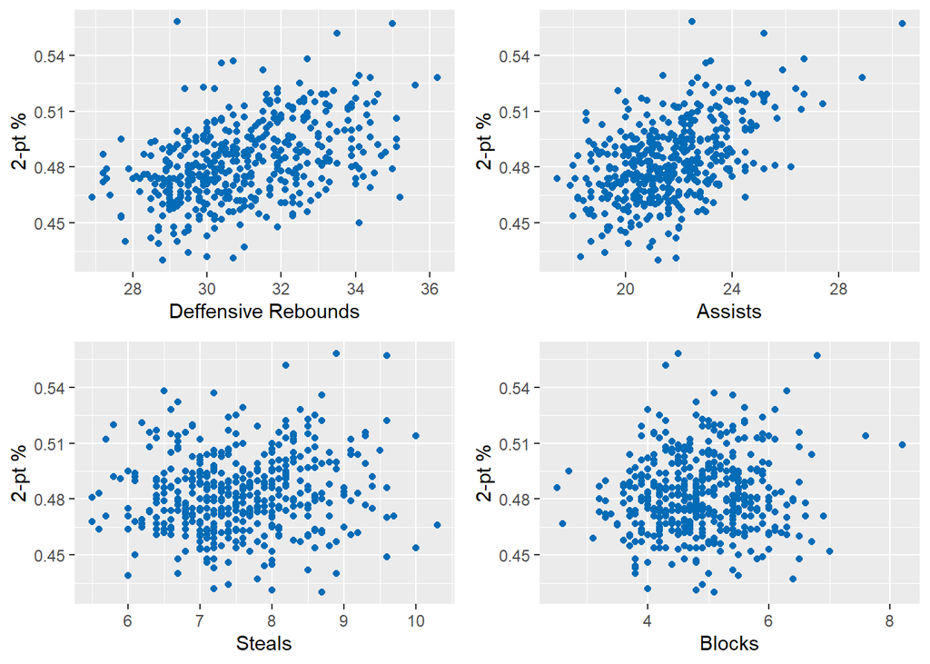

##### 2-pt %, TOV, PF, FT %, ORB and DRB

In four scatter plots below we can see a weak negative relationship between free throw % and offensive rebounds. It makes sense that their is some sort of negative relationship because more missed free throws leads to more offensive rebound opportunities. However, this relationship is weaker than previously stated relationships with FT % such as 2-pt % because their are less free throws in a game, less missed ones as it is a high probability shot and their is only rebound opportunity after the last free throw in a set. For example, if a player gets two free throws and misses both the players can only rebound after the second. The other three plots show no apparent relationship.

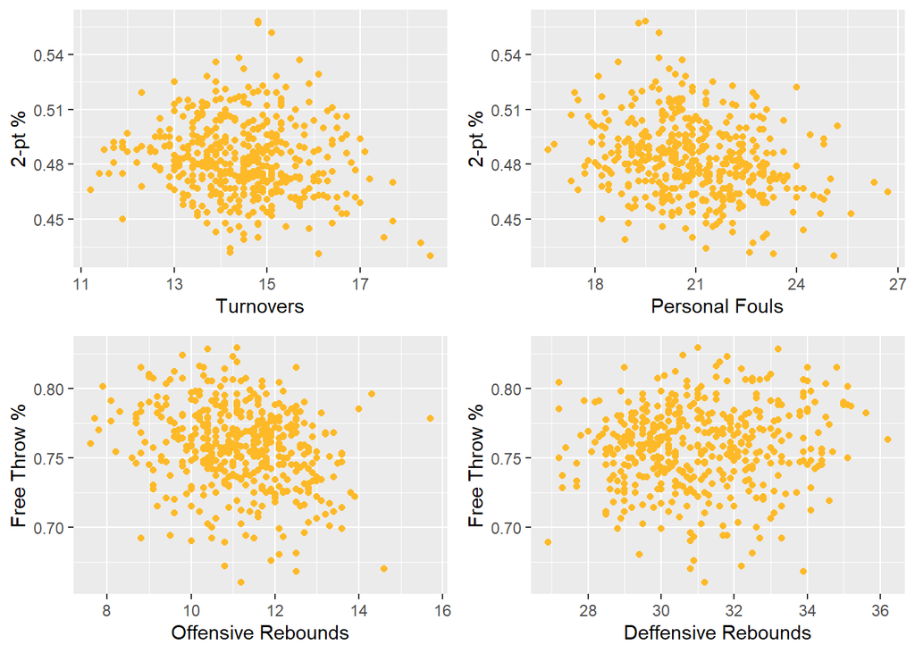

##### FT %, AST, BLK and TOV

In the four plots below there doesn’t appear to be any obvious relationships between any of the variables.

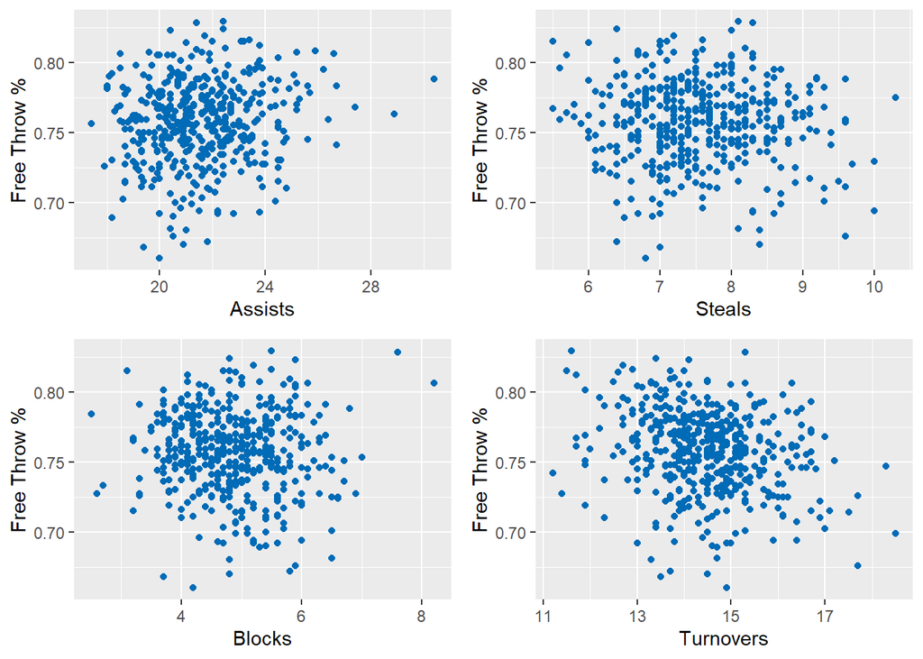

##### FT %, PF, ORB, DRB, AST and STL

In the four plots below there doesn’t appear to be any obvious relationships between any of the variables.

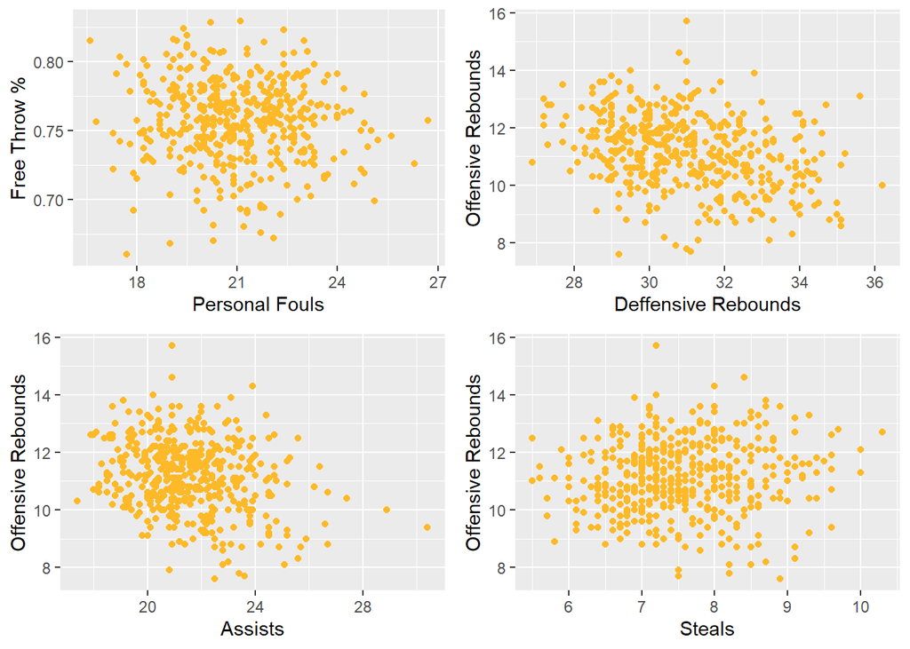

##### ORB, BLK, TOV, PF, DRB and AST

In the four scatter plots below we can see a weak positive relationship between defensive rebounds and assists. The possible logic behind this could be that a player who usually gets rebounds is often a big center or forward and does not take the ball up the court. Instead they pass it to one of the smaller guards who has better ball handling skills. This pass may lead to a basket and therefore an assist. This logic however is a stretch. The other three plots show no apparent relationship.

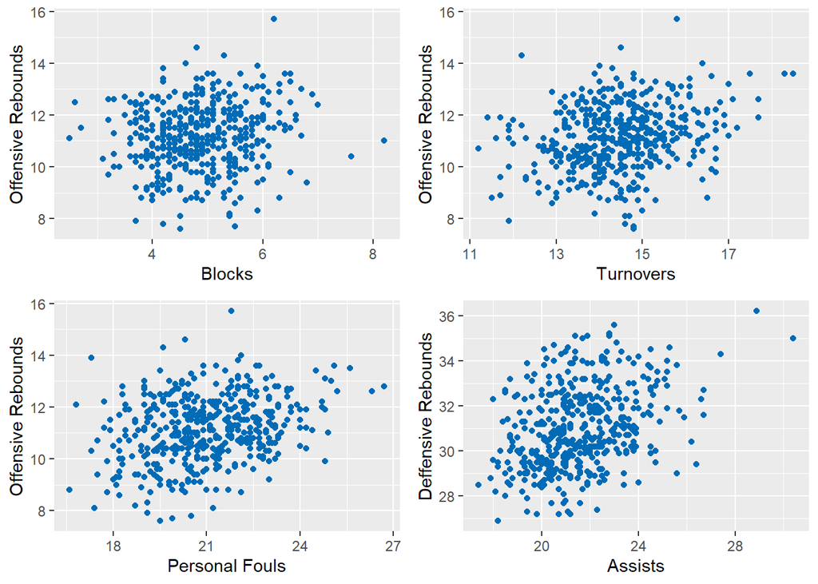

##### DRB, STL, BLK, TOV and PF

In the four scatter plots below we can see a negative relationship between defensive rebounds and personal fouls. The logic on this relationship is not clear. A defensive rebound is unlikely to lead to a personal foul and a personal foul cannot lead to a defensive rebound.

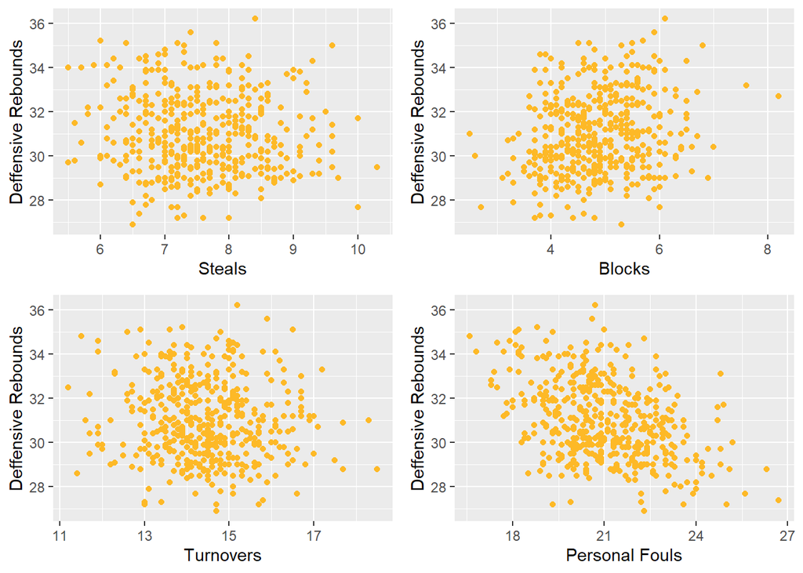

##### AST, STL, BLK, TOV and PF

In the four scatter plots below we see there is no clear relationship between any of the variables. This makes sense for all pairings below. For example, we would not expect assists and steals to be related. A team that gets a lot of assists does not translate to a lot of steals in any way.

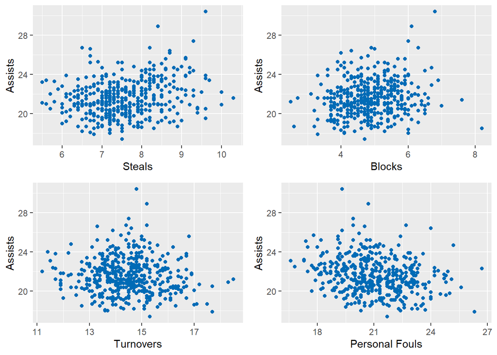

##### STL, BLK, TOV and PF

In the four scatter plots below there doesn’t appear to be any apparent relationships between the variables.

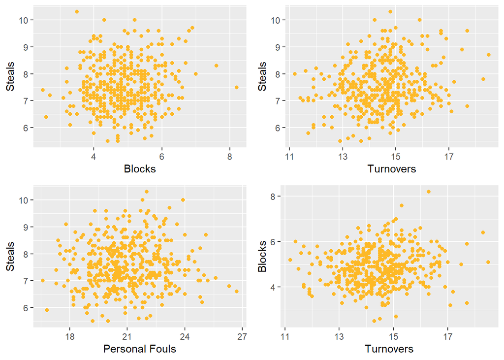

##### BLK, TOV and PF

In the two scatter plots below we see a positive relationship between personal fouls and turnovers. This makes sense because it is common for a turnover to lead to a personal foul. For example, if a player on offense loses the ball to the other team by making a bad pass, this will lead to a breakaway for the team who intercepted the pass.On the chase down it is very common for the player who lost the ball to want to redeem there turnover by making a stop but often instead of a clean block this leads to a foul. On the other hand blocks and personal fouls should be completely unrelated. On a defensive play it can only be one or the other. The resulting scatter plot shows evidence of this.

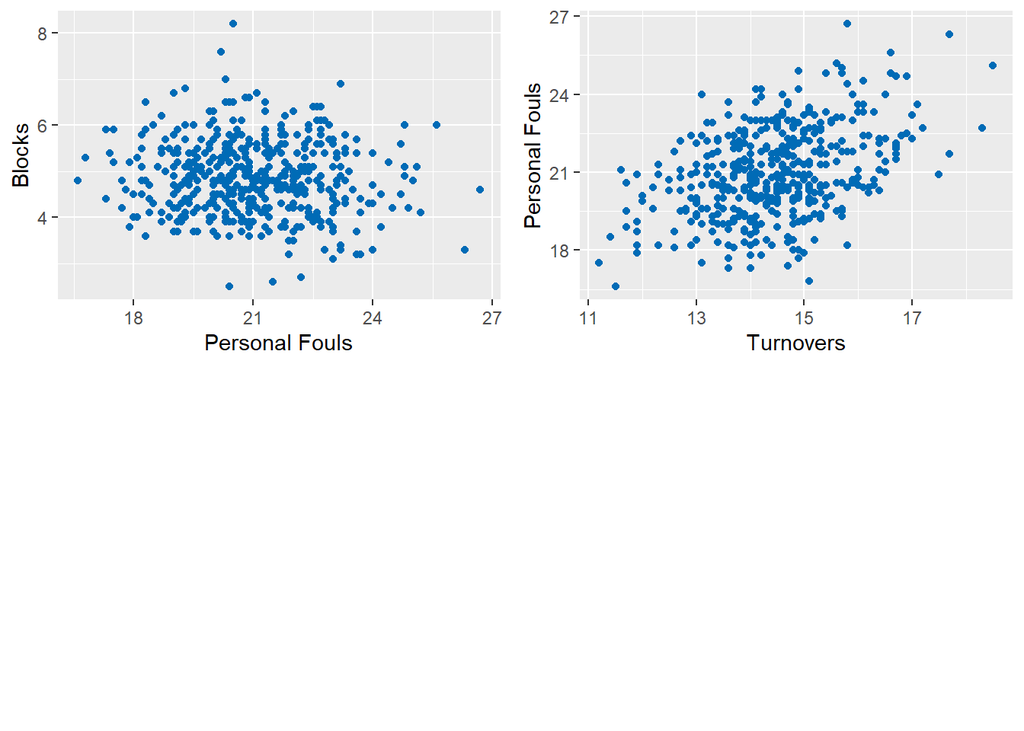

### Correlations

Below is a correlogram of all the quantitative variables in the data set. We can see that these correlations correspond to the relationships we noticed in the previous scatter plots. Notably, we can confirm the strong positive and negative relationships. For example, the strongest relationship in the data is between field goal % and 2-pt %, proven by its correlation of 0.88. The logic here is the same as previously mentioned. 2 point % is a proportion of field goal %. With this obvious relationship it would be logical to only include one of these two variables in the regression model to avoid multicollinearity. Further, the same is proven with FG % and 3-pt % as their correlation is 0.56. Next we can see several variables are positively correlated with wins with a correlation greater than or equal 0.5. Such as, FG %, 2-pt % and 3-pt %, these variables all bare the same logic in their support for wins. More shots made leads to more victories.

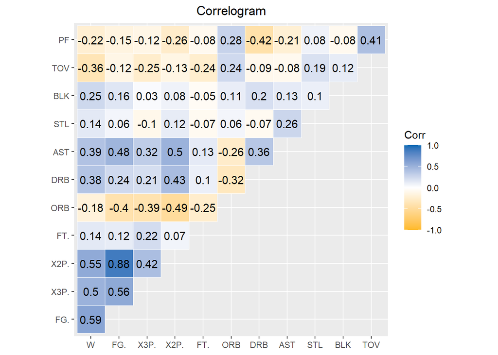

### 3 Point Era

Many people believe that once the 3-point era began, 3-point shooting has dominated the game and defense has been less important. The 3-point era does not have a set-in stone beginning. Nevertheless, many people believe Steph Curry fostered in the heavy 3-pt shooting around 2013. Evidence of this theory is shown in the below plot of 3-pt attempts over 15 seasons. It is clear that 3 point attempts across all teams increased after the 2010-2011 season and continued to increase every season after. To compare, the team with the lowest amount of 3-pt attempts in 2016-2017 is still higher than all the teams except one in the 2002-2003 season.

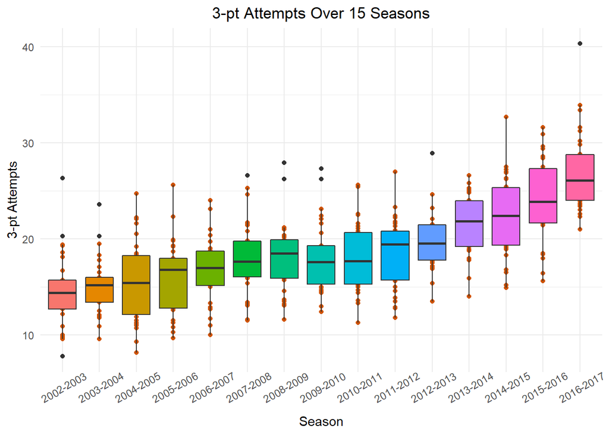

### Decline in 2-point Attempts

Opposite to 3-pt attempts we observe in the plot below, 2-pt attempts appear to decrease slightly from the 2012-2013 season onward. Clearly the style of play has changed over the years. Teams in more recent years are shooting less 2 pointers and more 3 pointers. With this evidence, it will be interesting to see when building a regression model, if either of these predictors are significant. Further, assuming both are significant predictors, comparing models that include just one will be of interest.

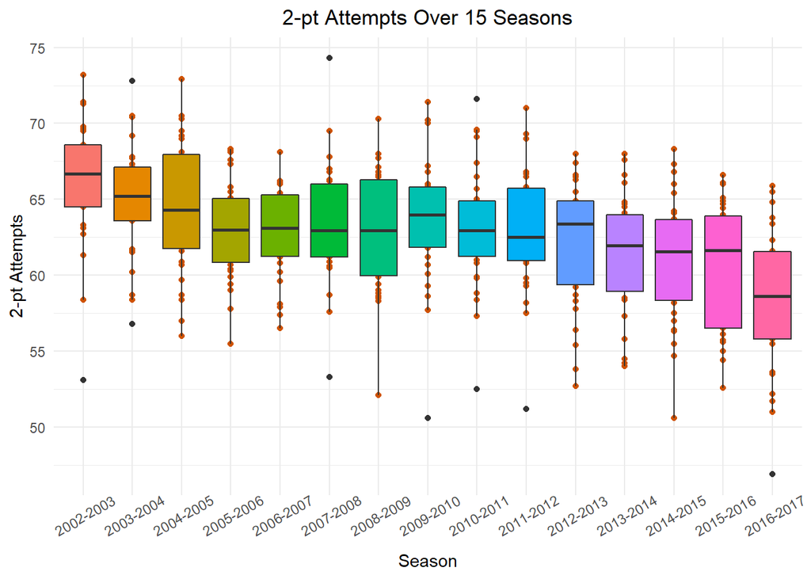